# Reproducible Research: Peer Assessment 1

## Loading and preprocessing the data

This section will set the working directory  
Read the csv file into a data frame  
Transform the date column to a date type  
Finally install dplyr and ggplot2 packages for use later

```r
setwd('/Users/jonporterjones/Coursera/ReproducibleResearch/AssignmentI/Repo/RepData_PeerAssessment1')
SourceData=read.csv('activity.csv')
SourceData$date=as.Date(SourceData$date)
install.packages("dplyr", repos="http://cran.rstudio.com/")
library(dplyr)
```

```r
install.packages("ggplot2", repos="http://cran.rstudio.com/")
```

[output not shown]

```r
library(ggplot2)
```

## What is mean total number of steps taken per day?

1. Make a histogram of the total number of steps taken each day
2. Calculate and report the **mean** and **median** total number of steps taken per day

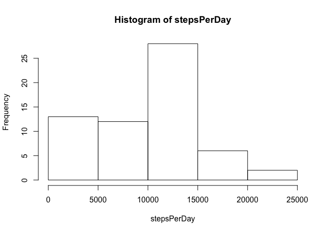

```r
stepsPerDay=with(SourceData,tapply(steps,date,sum,na.rm=T))
hist(stepsPerDay)
```

```r
mean(stepsPerDay)
```

```
## [1] 9354.23
```

```r
median(stepsPerDay)
```

```
## [1] 10395
```

## What is the average daily activity pattern?

1. Make a time series plot (i.e. `type = "l"`) of the 5-minute interval (x-axis) and the average number of steps taken, averaged across all days (y-axis)
2. Which 5-minute interval, on average across all the days in the dataset, contains the maximum number of steps?  
   **Comments**
- first use tapply to group source data by interval and get the mean of steps
- The result of this is an array, force this to a dataframe by converting the interval back to an integer and coercing the array containing the averages into a vector
- then create the plot using the data frame.
- the last line will give you the row from the data frame containing the highest average. It is ** Interval 835 ** and this is consistent with our plot

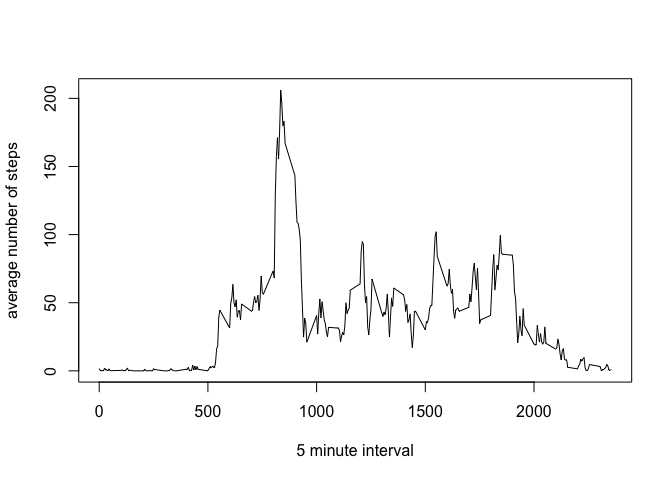

```r
AverageByInterval=with(SourceData,tapply(steps,interval,mean,na.rm=T))
AverageByIntervalFrame = data.frame("Interval"=as.integer(names(AverageByInterval)),"Average"=as.vector(AverageByInterval))
plot(AverageByIntervalFrame$Interval,AverageByIntervalFrame$Average,type="l",xlab="5 minute interval",ylab="average number of steps")
```

```r
AverageByIntervalFrame[AverageByIntervalFrame$Average==max(AverageByIntervalFrame$Average),]
```

```
##     Interval  Average
## 104      835 206.1698
```